# Preliminary study (interface selection) analysis

# Set up

## How to compile this file

We recommend loading this repository as a new project in RStudio (File -> New Project -> Existing directory and choosing `[your-path]/supplemental_material/`). Then, you can run code chunks individually or “Knit” the entire markdown file. RStudio should handle working directories for you.

If you choose to compile the file manually, make sure te Rmd working directory is same directory that contains this file (use ‘getwd()’). The path should look like `[your-path]/supplemental_material/Main_Study_Analysis/`. Use ‘setwd()’ if not.

## Libraries required for this analysis

Some of the libraries below require particular installation instructions (rstan). See comments in the code chunk below.

The `import` library is also required to run this code, which can be installed via `install.packages("import")`.

```r
library(dplyr)
```

```r
import::from(plyr, ddply, rename)
library(magrittr)   #pipe syntax (%>%, %<>%, etc)
library(ggplot2)
library(lme4)
library(forcats)
library(tidyr)
import::from(gamlss.dist, dTF, qTF, pTF, rTF)   #the TF functions are a scaled and shifted t distribution
import::from(LaplacesDemon, KLD)
import::from(MASS, parcoord)

# for RStan installation instructions, see https://github.com/stan-dev/rstan/wiki/RStan-Getting-Started
# DO NOT attempt to install rstan using install.packages(), as it will likely fail. Unfortunately its
# installation is finicky, and we recommend following the instructions on that page to the letter.
library(rstan)

library(brms)
```

## Ggplot theme + stan options

```r
theme_set(theme_bw())
options(mc.cores = parallel::detectCores())
```

# Create (discretized) reference distribution

Create a discretized normal distribution for a fixed interval size to represent the reference distribution shown to participants.

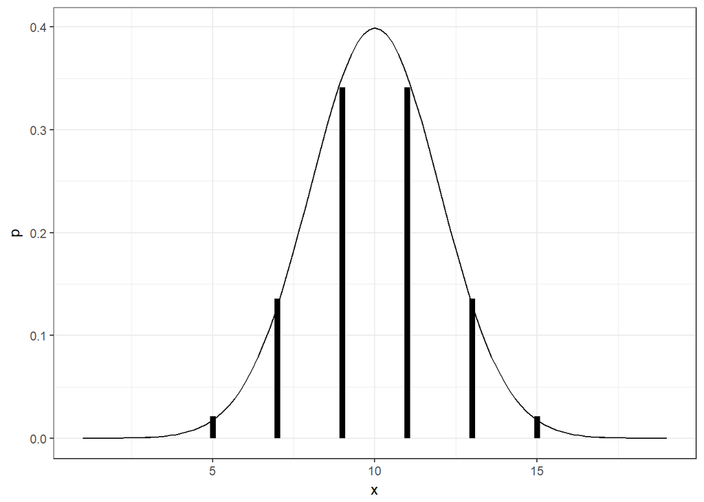

```r
mu = 10
sd = 2

min_x = 0
max_x = 20
interval_size = 2

#derive discrete reference distribution
make_discrete_reference_dist = function(dist_fun, min_x, max_x, interval_size) {
  data_frame(
    x_min = seq(min_x, max_x - interval_size, by = interval_size),
    x_max = seq(min_x + interval_size, max_x, by = interval_size),
    x = (x_min + x_max)/2,   #midpoint of the interval
    #this difference sometimes comes out as 0 due to rounding errors in bins with very low probability
    #adjust it to always be at least epsilon (smallest value > 0 on this machine
    #such that x + eps != x is always true).
    p = pmax(.Machine$double.eps, dist_fun(x_max) - dist_fun(x_min))
  )
}

#derive discrete analog
correct_dist = make_discrete_reference_dist(function(x) pnorm(x, mu, sd), min_x, max_x, interval_size)
  #remember to change to interval_size=1 for 100 balls

#check what it looks like:
correct_dist %>%
    ggplot(aes(x = x, y = p)) +
    stat_function(fun = function(x) dnorm(x, mu, sd) * interval_size) +
    geom_segment(aes(xend = x, y = 0, yend = p), size = 2)
```

# Read in data

## HCI listserv participants

```r
df <- read.csv("anonymized_survey_response_dists_with_order_forR_infovis.txt", sep="\t", row.names=NULL)
```

## Turk participants

```r
df2 <- read.csv("anonymized_survey_turk_response_dists_with_order_forR_infovis.txt", sep="\t", row.names=NULL)
colnames(df)
```

```
##  [1] "email"        "condition"    "nballs"       "nbins"
##  [5] "binint"       "binprob"      "slider"       "time"
##  [9] "order"        "nresponsebin"
```

# KL divergence

Since the code for KL divergence requires n_balls and interval size, split up the data into 3 dataframes, one for n=20, one for n=50, one for n=100

```r
df20 <- subset(df, df$nballs=="20")
df50 = subset(df, df$nballs=="50")
df100 = subset(df, df$nballs=="100")

df220 <- subset(df2, df2$nballs=="20")
df250 = subset(df2, df2$nballs=="50")
df2100 = subset(df2, df2$nballs=="100")
```

## Discrete interfaces

### Create reference distribution for 20 and 50 outcome interfaces

```r
#for 20 and 50 circles
correct_dist = make_discrete_reference_dist(function(x) pnorm(x, mu, sd), min_x, max_x, interval_size)
```

### Function to calculate KL divergence

```r
#function to calculate
kld_discrete = function(reference_dist, guesses) {
  #responses with 20 balls appear to be recorded as being out of 100, so
  #instead of assuming some number here we'll just make this out of the
  #total of the supplied guesses
  guesses = guesses / sum(guesses)
  smoothing_denominator = 1000
  n_atoms = nrow(correct_dist)
  #make sure the number of supplied guesses is the same as the atoms in the reference dist
  stopifnot(n_atoms == length(guesses))
  #calculate smoothed guesses (guaranteed to have no 0s and sum to 1)
  estimated_p = (guesses * smoothing_denominator + 1) / (smoothing_denominator + n_atoms)
  #assert we have normalized everything correctly (within a reasonable tolerance)
 # stopifnot(isTRUE(all.equal(sum(reference_dist$p), 1, tolerance = 0.00001)))
#  stopifnot(isTRUE(all.equal(sum(estimated_p), 1, tolerance = 0.00001)))
  #since we have normalized everything correctly, we can use the KLD formula directly
  #instead of calling KLD (which renormalizes again)
  sum(reference_dist$p * (log(reference_dist$p) - log(estimated_p)))
}
```

### Calculate KL divergence for 20 and 50 outcome discrete interfaces

```r
#Note that we must convert binprob, which loosk like 0,0,5,15,30,30,15,5,0,0, into a vector for each data set

#HCI listserv participants (df)
df20$kl = apply(df20, 1, function(row) {
  guesses = as.numeric(strsplit(as.character(row["binprob"]), ",")[[1]])
  kld_discrete(correct_dist, guesses)
})

df50$kl = apply(df50, 1, function(row) {
  guesses = as.numeric(strsplit(as.character(row["binprob"]), ",")[[1]])
  kld_discrete(correct_dist, guesses)
})

#MTurk participants (df2)
df220$kl = apply(df220, 1, function(row) {
  guesses = as.numeric(strsplit(as.character(row["binprob"]), ",")[[1]])
  kld_discrete(correct_dist, guesses)
})

df250$kl = apply(df250, 1, function(row) {
  guesses = as.numeric(strsplit(as.character(row["binprob"]), ",")[[1]])
  kld_discrete(correct_dist, guesses)
})
```

### Calculate KL divergence for 100 outcome discrete interfaces

```r
#Change interval size and recreate reference distribution
interval_size = 1
correct_dist = make_discrete_reference_dist(function(x) pnorm(x, mu, sd), min_x, max_x, interval_size)

df100$kl = apply(df100, 1, function(row) {
  guesses = as.numeric(strsplit(as.character(row["binprob"]), ",")[[1]])
  kld_discrete(correct_dist, guesses)
})

df2100$kl = apply(df2100, 1, function(row) {
  guesses = as.numeric(strsplit(as.character(row["binprob"]), ",")[[1]])
  kld_discrete(correct_dist, guesses)
})
```

## Continuous interfaces

### Create reference distribution

```r
min_x = 0
max_x = 20
mu = 10
sd = 2

interval_size = 2
correct_dist = make_discrete_reference_dist(function(x) pnorm(x, mu, sd), min_x, max_x, interval_size)
```

### Function to calculate KL divergence

```r
y_to_density = function(x, estimated_y) {
    user_density = approxfun(x, estimated_y)
    area_under_curve = integrate(user_density, lower = min(x), upper = max(x))$value
    #finally, a similar smoothing as applied in the discrete case to ensure there are no 0s
    #see kl-divergence-for-discrete-dist.Rmd
    #might want to revisit this smoothing in the other files and make them all exactly the same?
    #(i.e. here we assume fractions out of 1000, while in the other file we used 100 and 20 depending
    #on number of balls --- but this could make the KLD higher for those conditions just because of
    #differences in smoothing parameters)
    (estimated_y / area_under_curve * 1000 + 1) / (1000 + length(x))
}
```

### Calculate KL divergence for continuous interfaces

```r
#Divide data in HCI listserv and MTurk participants
dfc=subset(df, df$condition == "drawcontline" | df$condition=="drawcontfill")
dfc2=subset(df2, df2$condition == "drawcontline" | df2$condition=="drawcontfill")

klsc <- vector()
for(i in 1:length(dfc$binprob)){
  estimated_y = strsplit(as.character(dfc$binprob[i]), ",")
  estimated_y = as.numeric(estimated_y[[1]])
  #interval_size = 1
  guesses = correct_dist %>%
    mutate(
        estimated_p = y_to_density(c(2,4,6,8,10,12,14,16,18,20), estimated_y)
    )
   klsc = append(klsc, guesses %$% KLD(pnorm(x + interval_size/2, mu, sd) - pnorm(x - interval_size/2, mu, sd), estimated_p)$sum.KLD.px.py)
}
dfc = cbind(dfc, klsc)

#MTurk participants
klsc <- vector()
for(i in 1:length(dfc2$binprob)){
  estimated_y = strsplit(as.character(dfc2$binprob[i]), ",")
  estimated_y = as.numeric(estimated_y[[1]])
  guesses = correct_dist %>%
    mutate(
        estimated_p = y_to_density(c(2,4,6,8,10,12,14,16,18,20), estimated_y)
    )
   klsc = append(klsc, guesses %$% KLD(pnorm(x + interval_size/2, mu, sd) - pnorm(x - interval_size/2, mu, sd), estimated_p)$sum.KLD.px.py)
}
dfc2 = cbind(dfc2, klsc)
```

# Descriptive Statistics

## Time and slider

```r
#time by sample
ddply(df, ~condition, summarise, mean=mean(time, na.rm=TRUE), sd=sd(time, na.rm=TRUE))
```

```
##          condition      mean        sd
## 1       addclick20  79.62271  39.02237
## 2       addclick50 107.49000 162.96599
## 3     drawcontfill  59.30107  36.95526
## 4     drawcontline  68.54100  50.78739
## 5     paintdrag100  93.57162  86.63774
## 6      paintdrag20  54.31831  32.69544
## 7  paintdragtop100 143.64664 154.00359
## 8   paintdragtop20  36.63391  26.32624
## 9        pullup100 146.04012 106.43985
## 10        pullup20  78.19735  56.47695
## 11         roll100 121.81924  82.55063
## 12          roll20  65.59324  41.26528
```

```r
ddply(df2, ~condition, summarise, mean=mean(time, na.rm=TRUE), sd=sd(time, na.rm=TRUE))
```

```
##          condition      mean        sd
## 1       addclick20  87.78892  49.38196
## 2       addclick50  84.90518  61.83295
## 3     drawcontfill  70.39176  62.14436
## 4     drawcontline  85.07624  62.66903
## 5     paintdrag100  99.23718  62.88856
## 6      paintdrag20  85.38850  98.77070
## 7  paintdragtop100 117.13139  67.69758
## 8   paintdragtop20  62.12800  45.21508
## 9        pullup100 163.02878 184.25314
## 10        pullup20  96.59567  92.30244
## 11         roll100 162.38478 116.10252
## 12          roll20  90.09354  66.60117
```

```r
#slider by sample
#first transform to numeric

df2$slider <- as.numeric(paste(df2$slider))

ddply(df, ~condition, summarise, mean=mean(slider, na.rm=TRUE), sd=sd(slider, na.rm=TRUE))
```

```
##          condition     mean       sd
## 1       addclick20 35.88235 29.40213
## 2       addclick50 37.68750 35.75606
## 3     drawcontfill 64.71429 24.84236
## 4     drawcontline 56.06667 30.54380
## 5     paintdrag100 57.84615 36.97938
## 6      paintdrag20 47.92308 33.55459
## 7  paintdragtop100 55.36364 38.35172
## 8   paintdragtop20 62.45455 26.39456
## 9        pullup100 55.11765 30.34156
## 10        pullup20 57.82353 28.73420
## 11         roll100 29.05882 29.98014
## 12          roll20 33.94118 23.97778
```

```r
ddply(df2, ~condition, summarise, mean=mean(slider, na.rm=TRUE), sd=sd(slider, na.rm=TRUE))
```

```
##          condition     mean       sd
## 1       addclick20 41.52632 28.79915
## 2       addclick50 46.65789 27.28456
## 3     drawcontfill 65.15556 28.74176
## 4     drawcontline 63.04444 28.03079
## 5     paintdrag100 59.75000 27.57431
## 6      paintdrag20 45.03571 26.41476
## 7  paintdragtop100 47.60976 33.32032
## 8   paintdragtop20 43.35714 29.22480
## 9        pullup100 54.97561 33.88398
## 10        pullup20 42.94872 29.80635
## 11         roll100 31.24390 29.08761
## 12          roll20 28.75610 25.41533
```

## KL Divergence prep

### Combine samples and record sample type

```r
dfc = rename(dfc, c("klsc"="kl"))
dfc2 = rename(dfc2, c("klsc"="kl"))

adf <- rbind(df20, df50, df100, dfc)
#below line is doing something weird
adf2 <- rbind(df220, df250, df2100, dfc2)
#get rid of erroneous extra emails that create unnecessary levels
adf2 <- droplevels(adf2)

adf$pop = "Univ"
adf2$pop = "Turk"

adfA = rbind(adf, adf2)
#adfA$cond_type <- ifelse(adfA$condition=="addclick20" | adfA$condition=="addclick50", "balls_bins", ifelse(adfA$condition=="pullup20" | adfA$condition=="pullup100", "pullup", ifelse(adfA$condition=="roll20" | adfA$condition=="roll100", "roll", ifelse(adfA$condition=="paintdrag20" | adfA$condition=="paintdrag100", "paintdrag", ifelse(adfA$condition=="paintdragtop20" | adfA$condition=="paintdragtop100", "paintdragtop", "continuous")))))
```

## KL divergence

```r
#take the log
adf$logkl <- log(adf$kl)

ddply(adf, ~condition, summarise, mean=mean(logkl, na.rm=TRUE), sd=sd(kl, na.rm=TRUE))
```

```
##          condition      mean        sd
## 1       addclick20 -1.793192 0.1555377
## 2       addclick50 -1.763870 0.7389339
## 3     drawcontfill -2.796563 0.2549848
## 4     drawcontline -1.856026 0.1809337
## 5     paintdrag100 -1.161971 1.4106681
## 6      paintdrag20 -1.499374 1.4554068
## 7  paintdragtop100 -1.409808 0.2767240
## 8   paintdragtop20 -1.308879 0.2947947
## 9        pullup100 -1.998669 0.3959058
## 10        pullup20 -2.104653 0.2167287
## 11         roll100 -1.058898 0.2316108
## 12          roll20 -1.630268 0.2502557
```

# Modeling

## Prepare data for mixed effects model

```r
adfA %<>% mutate(
  # move addlcick50 to the front to make it the intercept in the dummy-coded model
  condition = fct_relevel(condition, "addclick50"),
  pop = factor(pop),
  slider = as.numeric(slider),
  subject = factor(email),
  mturk = pop != "Univ"
)
```

## KL divergence

### Frequentist model

```r
kl_lme4 <- lmer( log(kl) ~ condition + mturk + (1 | subject), data = adfA)
```

```r
summary(kl_lme4)
```

```
## Linear mixed model fit by REML ['lmerMod']
## Formula: log(kl) ~ condition + mturk + (1 | subject)
##    Data: adfA
##
## REML criterion at convergence: 1528.6
##
## Scaled residuals:
##     Min      1Q  Median      3Q     Max
## -3.3727 -0.5119 -0.0213  0.4754  4.1382
##
## Random effects:
##  Groups   Name        Variance Std.Dev.
##  subject  (Intercept) 0.1440   0.3795
##  Residual             0.5141   0.7170
## Number of obs: 645, groups:  subject, 107
##
## Fixed effects:
##                          Estimate Std. Error t value
## (Intercept)              -1.89063    0.12979 -14.566
## conditionaddclick20       0.08527    0.13743   0.620
## conditiondrawcontfill    -0.76072    0.13851  -5.492
## conditiondrawcontline     0.18171    0.13784   1.318
## conditionpaintdrag100     0.36936    0.15500   2.383
## conditionpaintdrag20      0.27978    0.15500   1.805
## conditionpaintdragtop100  0.40077    0.14572   2.750
## conditionpaintdragtop20   0.55595    0.14504   3.833
## conditionpullup100        0.01141    0.14014   0.081
## conditionpullup20        -0.09570    0.14124  -0.678
## conditionroll100          0.57387    0.14006   4.097
## conditionroll20           0.60181    0.14006   4.297
## mturkTRUE                 0.23661    0.10345   2.287
```

```
##
## Correlation matrix not shown by default, as p = 13 > 12.
## Use print(x, correlation=TRUE)  or
##   vcov(x)     if you need it
```

### Bayesian model

```r
kl_g2s <- brm(log(kl) ~ condition + order + mturk + (1 | subject), data = adfA)
kl_g2s
```

```
##  Family: gaussian(identity)
## Formula: log(kl) ~ condition + order + mturk + (1 | subject)
##    Data: adfA (Number of observations: 599)
## Samples: 4 chains, each with iter = 2000; warmup = 1000; thin = 1;
##          total post-warmup samples = 4000
##     ICs: LOO = Not computed; WAIC = Not computed
##
## Group-Level Effects:
## ~subject (Number of levels: 102)
##               Estimate Est.Error l-95% CI u-95% CI Eff.Sample Rhat
## sd(Intercept)     0.39      0.05      0.3     0.48       1627    1
##
## Population-Level Effects:
##                          Estimate Est.Error l-95% CI u-95% CI Eff.Sample
## Intercept                   -1.79      0.15    -2.07    -1.48       2367
## conditionaddclick20          0.07      0.14    -0.23     0.34       2580
## conditiondrawcontfill       -0.76      0.15    -1.06    -0.47       2253
## conditiondrawcontline        0.22      0.15    -0.08     0.51       2392
## conditionpaintdrag100        0.43      0.16     0.11     0.74       2501
## conditionpaintdrag20         0.30      0.16    -0.02     0.62       2596
## conditionpaintdragtop100     0.53      0.16     0.21     0.84       2251
## conditionpaintdragtop20      0.65      0.15     0.35     0.95       2281
## conditionpullup100           0.03      0.15    -0.26     0.32       2296
## conditionpullup20           -0.08      0.15    -0.36     0.21       2285
## conditionroll100             0.66      0.15     0.36     0.97       2338
## conditionroll20              0.62      0.15     0.33     0.90       2344
## order                       -0.04      0.02    -0.08     0.00       4000
## mturkTRUE                    0.24      0.11     0.02     0.45       3148
##                          Rhat
## Intercept                   1
## conditionaddclick20         1
## conditiondrawcontfill       1
## conditiondrawcontline       1
## conditionpaintdrag100       1
## conditionpaintdrag20        1
## conditionpaintdragtop100    1
## conditionpaintdragtop20     1
## conditionpullup100          1
## conditionpullup20           1
## conditionroll100            1
## conditionroll20             1
## order                       1
## mturkTRUE                   1
##
## Family Specific Parameters:
##       Estimate Est.Error l-95% CI u-95% CI Eff.Sample Rhat
## sigma     0.73      0.02     0.68     0.78       4000    1
##
## Samples were drawn using sampling(NUTS). For each parameter, Eff.Sample
## is a crude measure of effective sample size, and Rhat is the potential
## scale reduction factor on split chains (at convergence, Rhat = 1).
```

Note: Some readers may experience an error in generating the plot due to a known bug with plotting rstan model fits when using using some versions of ggplot2. (https://github.com/tidyverse/ggplot2/blob/master/revdep/problems.md)

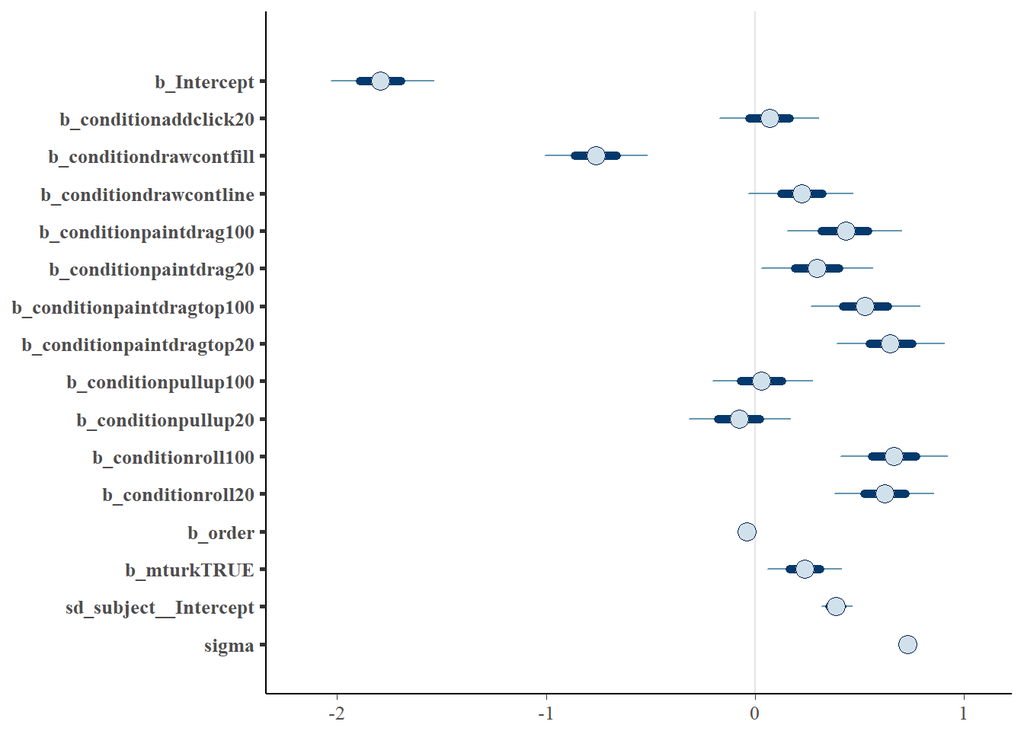

```r
stanplot(kl_g2s)
```

#### Expected values of mean by condition

```r
adfA %>%
  expand(condition, order = 1, mturk = FALSE) %>%
  cbind(fitted(kl_g2s, newdata = ., re_formula = NA))
```

```
##          condition order mturk  Estimate Est.Error   2.5%ile   97.5%ile
## 1       addclick50     1 FALSE -1.829606 0.1425102 -2.101467 -1.5355852
## 2       addclick20     1 FALSE -1.763834 0.1344892 -2.031351 -1.5043147
## 3     drawcontfill     1 FALSE -2.593111 0.1426613 -2.871004 -2.3135093
## 4     drawcontline     1 FALSE -1.607676 0.1382071 -1.883542 -1.3362081
## 5     paintdrag100     1 FALSE -1.399264 0.1559258 -1.703391 -1.0932857
## 6      paintdrag20     1 FALSE -1.532390 0.1522095 -1.827806 -1.2385515
## 7  paintdragtop100     1 FALSE -1.303289 0.1664340 -1.624656 -0.9804616
## 8   paintdragtop20     1 FALSE -1.183536 0.1541453 -1.493894 -0.8792598
## 9        pullup100     1 FALSE -1.799039 0.1448433 -2.084149 -1.5201252
## 10        pullup20     1 FALSE -1.906605 0.1404009 -2.182691 -1.6261303
## 11         roll100     1 FALSE -1.166106 0.1516869 -1.461725 -0.8695301
## 12          roll20     1 FALSE -1.210781 0.1383559 -1.483872 -0.9442475
```

#### To compare university and MTurk samples

Extract coef for difference in Univ vs mturk:

```r
fixef(kl_g2s)["mturkTRUE",]
```

```
## The 'fixef' method has been revised in brms 1.7.0.
## To get the old output, set argument 'old' to TRUE.
```

```
##   Estimate  Est.Error    2.5%ile   97.5%ile
## 0.23666625 0.10806107 0.02303326 0.44704995
```

## Time

### Frequentist model

```r
time_lme4 <- lmer( time ~ condition + mturk + (1 | subject) , data=adfA )
summary(time_lme4)
```

```
## Linear mixed model fit by REML ['lmerMod']
## Formula: time ~ condition + mturk + (1 | subject)
##    Data: adfA
##
## REML criterion at convergence: 7452.5
##
## Scaled residuals:
##     Min      1Q  Median      3Q     Max
## -2.2353 -0.4178 -0.1159  0.1932 12.3008
##
## Random effects:
##  Groups   Name        Variance Std.Dev.
##  subject  (Intercept) 1567     39.58
##  Residual             6105     78.13
## Number of obs: 645, groups:  subject, 107
##
## Fixed effects:
##                          Estimate Std. Error t value
## (Intercept)                83.285     13.966   5.964
## conditionaddclick20        -5.914     14.976  -0.395
## conditiondrawcontfill     -26.690     15.080  -1.770
## conditiondrawcontline     -12.785     15.008  -0.852
## conditionpaintdrag100      11.315     16.864   0.671
## conditionpaintdrag20      -10.589     16.864  -0.628
## conditionpaintdragtop100   28.978     15.853   1.828
## conditionpaintdragtop20   -36.571     15.779  -2.318
## conditionpullup100         64.301     15.252   4.216
## conditionpullup20          -2.555     15.372  -0.166
## conditionroll100           53.035     15.244   3.479
## conditionroll20           -14.548     15.244  -0.954
## mturkTRUE                  13.006     10.975   1.185
```

```
##
## Correlation matrix not shown by default, as p = 13 > 12.
## Use print(x, correlation=TRUE)  or
##   vcov(x)     if you need it
```

### Bayesian model

```r
time_g2s <- brm(time ~ condition + order + mturk + (1 | subject), data = adfA)
time_g2s
```

```
##  Family: gaussian(identity)
## Formula: time ~ condition + order + mturk + (1 | subject)
##    Data: adfA (Number of observations: 599)
## Samples: 4 chains, each with iter = 2000; warmup = 1000; thin = 1;
##          total post-warmup samples = 4000
##     ICs: LOO = Not computed; WAIC = Not computed
##
## Group-Level Effects:
## ~subject (Number of levels: 102)
##               Estimate Est.Error l-95% CI u-95% CI Eff.Sample Rhat
## sd(Intercept)     40.7      4.96     31.6    50.95       1765    1
##
## Population-Level Effects:
##                          Estimate Est.Error l-95% CI u-95% CI Eff.Sample
## Intercept                  103.88     16.11    72.52   135.05       2727
## conditionaddclick20        -13.96     15.55   -45.01    16.76       2515
## conditiondrawcontfill      -29.83     15.60   -60.75     0.43       2596
## conditiondrawcontline      -18.04     15.42   -48.11    12.32       2526
## conditionpaintdrag100       15.16     17.53   -19.37    49.29       2678
## conditionpaintdrag20       -13.70     17.94   -49.14    21.41       2820
## conditionpaintdragtop100    42.85     17.10     9.49    76.08       2518
## conditionpaintdragtop20    -30.23     16.56   -62.49     2.19       2315
## conditionpullup100          65.49     15.77    35.01    96.19       2153
## conditionpullup20           -5.17     16.00   -36.24    26.23       2429
## conditionroll100            61.10     16.22    28.59    93.05       2429
## conditionroll20            -14.21     16.04   -44.68    17.14       2336
## order                       -6.05      2.23   -10.29    -1.65       4000
## mturkTRUE                   12.94     11.44    -8.59    36.19       3444
##                          Rhat
## Intercept                   1
## conditionaddclick20         1
## conditiondrawcontfill       1
## conditiondrawcontline       1
## conditionpaintdrag100       1
## conditionpaintdrag20        1
## conditionpaintdragtop100    1
## conditionpaintdragtop20     1
## conditionpullup100          1
## conditionpullup20           1
## conditionroll100            1
## conditionroll20             1
## order                       1
## mturkTRUE                   1
##
## Family Specific Parameters:
##       Estimate Est.Error l-95% CI u-95% CI Eff.Sample Rhat
## sigma    78.97       2.5    74.17    83.87       4000    1
##
## Samples were drawn using sampling(NUTS). For each parameter, Eff.Sample
## is a crude measure of effective sample size, and Rhat is the potential
## scale reduction factor on split chains (at convergence, Rhat = 1).
```

Plot coefficients (again, known error with some ggplot2 versions may cause issues for some readers)

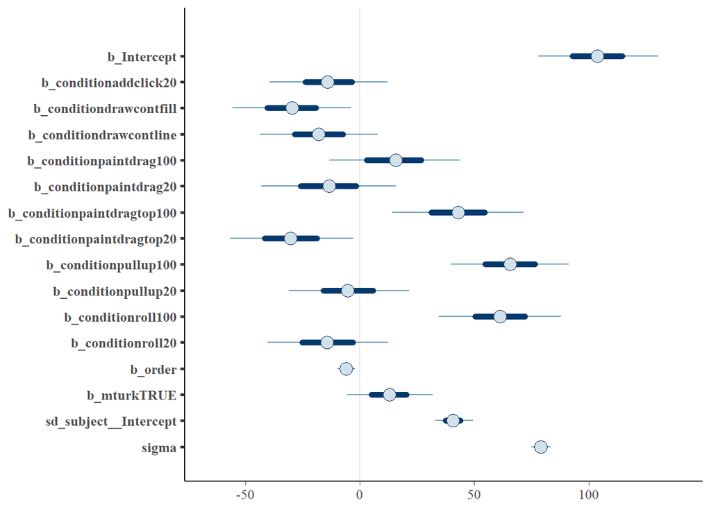

```r
stanplot(time_g2s)
```

#### Expected values of mean by condition

```r
adfA %>%
  expand(condition, order = 1, mturk = FALSE) %>%
  cbind(fitted(time_g2s, newdata = ., re_formula = NA))
```

```
##          condition order mturk  Estimate Est.Error   2.5%ile 97.5%ile
## 1       addclick50     1 FALSE  97.83333  15.26005  68.03542 127.7582
## 2       addclick20     1 FALSE  83.87674  14.25514  55.80230 110.6910
## 3     drawcontfill     1 FALSE  68.00302  15.51160  37.55621  98.2295
## 4     drawcontline     1 FALSE  79.79529  14.63039  51.98433 108.0764
## 5     paintdrag100     1 FALSE 112.99799  16.99302  80.38160 146.6976
## 6      paintdrag20     1 FALSE  84.13400  16.83854  50.66492 116.9214
## 7  paintdragtop100     1 FALSE 140.68138  18.02300 105.03345 175.4075
## 8   paintdragtop20     1 FALSE  67.60285  17.03293  34.91762 100.5043
## 9        pullup100     1 FALSE 163.32278  15.50398 133.09740 193.4575
## 10        pullup20     1 FALSE  92.66651  15.07314  62.77045 122.1849
## 11         roll100     1 FALSE 158.93175  16.56400 125.76500 191.4483
## 12          roll20     1 FALSE  83.62168  15.86697  52.05182 114.4970
```

#### To compare university and MTurk samples

Extract coef for difference in Univ vs mturk:

```r
fixef(time_g2s)["mturkTRUE",]
```

```
## The 'fixef' method has been revised in brms 1.7.0.
## To get the old output, set argument 'old' to TRUE.
```

```
##  Estimate Est.Error   2.5%ile  97.5%ile
## 12.937388 11.441587 -8.592542 36.193007
```

## Slider

### Frequentist model

```r
slider_lme4 <- lmer(slider ~ condition + mturk + (1 | subject) , data=adfA)
```

```r
summary(slider_lme4)
```

```
## Linear mixed model fit by REML ['lmerMod']
## Formula: slider ~ condition + mturk + (1 | subject)
##    Data: adfA
##
## REML criterion at convergence: 6094.8
##
## Scaled residuals:
##      Min       1Q   Median       3Q      Max
## -2.26745 -0.78016  0.05718  0.77500  2.05509
##
## Random effects:
##  Groups   Name        Variance Std.Dev.
##  subject  (Intercept) 150.9    12.28
##  Residual             727.0    26.96
## Number of obs: 645, groups:  subject, 107
##
## Fixed effects:
##                          Estimate Std. Error t value
## (Intercept)                46.398      4.687   9.900
## conditionaddclick20        -4.356      5.168  -0.843
## conditiondrawcontfill      21.055      5.192   4.055
## conditiondrawcontline      17.676      5.168   3.421
## conditionpaintdrag100      12.661      5.796   2.184
## conditionpaintdrag20       -0.534      5.796  -0.092
## conditionpaintdragtop100    3.205      5.448   0.588
## conditionpaintdragtop20     1.263      5.422   0.233
## conditionpullup100          9.748      5.247   1.858
## conditionpullup20           2.710      5.288   0.512
## conditionroll100          -16.334      5.245  -3.114
## conditionroll20           -16.662      5.245  -3.177
## mturkTRUE                  -1.624      3.562  -0.456
```

```
##
## Correlation matrix not shown by default, as p = 13 > 12.
## Use print(x, correlation=TRUE)  or
##   vcov(x)     if you need it
```

### Bayesian model

```r
slider_g2s <- brm(slider ~ condition + order + mturk + (1 | subject) , data = adfA)
slider_g2s
```

```
##  Family: gaussian(identity)
## Formula: slider ~ condition + order + mturk + (1 | subject)
##    Data: adfA (Number of observations: 599)
## Samples: 4 chains, each with iter = 2000; warmup = 1000; thin = 1;
##          total post-warmup samples = 4000
##     ICs: LOO = Not computed; WAIC = Not computed
##
## Group-Level Effects:
## ~subject (Number of levels: 102)
##               Estimate Est.Error l-95% CI u-95% CI Eff.Sample Rhat
## sd(Intercept)    12.31      1.71     9.07    15.84       1459    1
##
## Population-Level Effects:
##                          Estimate Est.Error l-95% CI u-95% CI Eff.Sample
## Intercept                   49.84      5.46    39.07    60.44       2456
## conditionaddclick20         -5.71      5.50   -16.59     4.83       2357
## conditiondrawcontfill       21.47      5.48    10.83    32.26       1816
## conditiondrawcontline       16.92      5.42     6.42    27.42       2098
## conditionpaintdrag100       14.05      6.16     1.98    26.18       2222
## conditionpaintdrag20        -1.27      6.06   -13.03    10.88       2223
## conditionpaintdragtop100     7.59      5.97    -3.83    19.53       1900
## conditionpaintdragtop20      4.44      5.80    -6.96    15.74       1989
## conditionpullup100          11.59      5.48     1.00    22.51       1913
## conditionpullup20            2.90      5.58    -8.10    14.05       2053
## conditionroll100           -14.95      5.67   -26.10    -3.63       1885
## conditionroll20            -15.13      5.58   -25.98    -4.07       1890
## order                       -1.22      0.76    -2.73     0.24       4000
## mturkTRUE                   -2.14      3.68    -9.28     5.07       3458
##                          Rhat
## Intercept                   1
## conditionaddclick20         1
## conditiondrawcontfill       1
## conditiondrawcontline       1
## conditionpaintdrag100       1
## conditionpaintdrag20        1
## conditionpaintdragtop100    1
## conditionpaintdragtop20     1
## conditionpullup100          1
## conditionpullup20           1
## conditionroll100            1
## conditionroll20             1
## order                       1
## mturkTRUE                   1
##
## Family Specific Parameters:
##       Estimate Est.Error l-95% CI u-95% CI Eff.Sample Rhat
## sigma    27.09      0.88    25.47    28.88       4000    1
##
## Samples were drawn using sampling(NUTS). For each parameter, Eff.Sample
## is a crude measure of effective sample size, and Rhat is the potential
## scale reduction factor on split chains (at convergence, Rhat = 1).
```

plot coefficients (again, known error with some ggplot2 versions may cause issues for some readers)

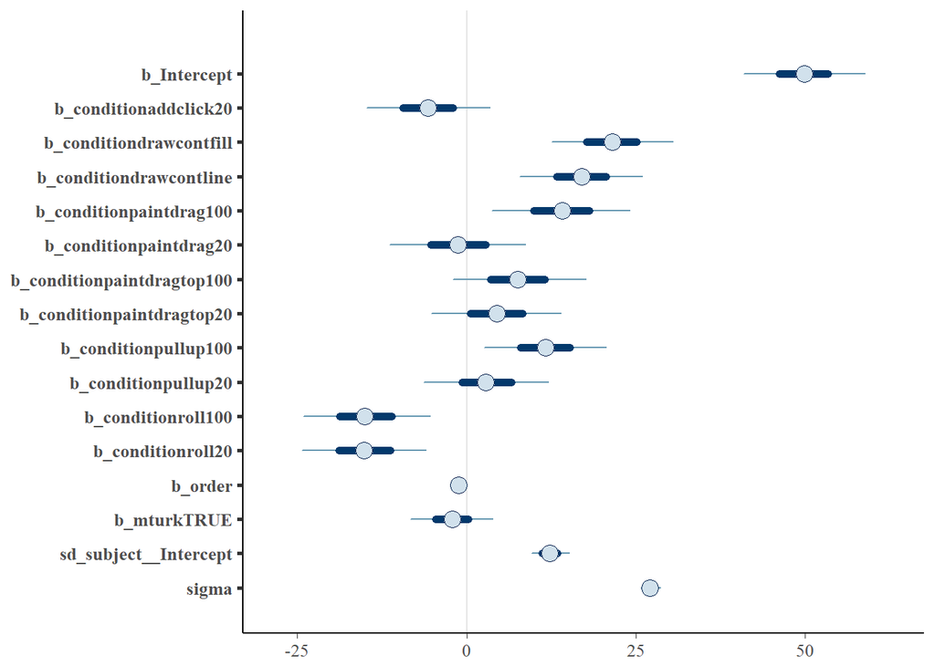

```r
stanplot(slider_g2s)
```

#### Expected values of mean by condition

```r
adfA %>%
  expand(condition, order = 1, mturk = FALSE) %>%
  cbind(fitted(slider_g2s, newdata = ., re_formula = NA))
```

```
##          condition order mturk Estimate Est.Error  2.5%ile 97.5%ile
## 1       addclick50     1 FALSE 48.62536  5.162873 38.41324 58.57287
## 2       addclick20     1 FALSE 42.91554  4.947895 33.45365 52.58795
## 3     drawcontfill     1 FALSE 70.09276  5.117038 60.09907 79.81722
## 4     drawcontline     1 FALSE 65.54295  4.866098 55.91341 74.88508
## 5     paintdrag100     1 FALSE 62.67404  5.574358 51.70207 73.64896
## 6      paintdrag20     1 FALSE 47.35738  5.332031 36.46622 57.70576
## 7  paintdragtop100     1 FALSE 56.21668  6.140536 44.28514 68.21255
## 8   paintdragtop20     1 FALSE 53.06278  5.771934 41.70773 64.22631
## 9        pullup100     1 FALSE 60.21807  5.248824 50.16277 70.44692
## 10        pullup20     1 FALSE 51.52110  5.014736 41.73748 61.25286
## 11         roll100     1 FALSE 33.67675  5.548928 22.73398 44.58132
## 12          roll20     1 FALSE 33.49375  5.182801 23.31506 43.90492
```

#### To compare university and MTurk samples

Extract coef for difference in Univ vs mturk:

```r
fixef(slider_g2s)["mturkTRUE",]
```

```
## The 'fixef' method has been revised in brms 1.7.0.
## To get the old output, set argument 'old' to TRUE.
```

```
##  Estimate Est.Error   2.5%ile  97.5%ile
## -2.144440  3.677899 -9.281576  5.074458
```